# Final Assignment, Task 3

Tue Minh Nguyen

22/10/2024

## Task 3 description

Task 3 focuses on analyzing the COVID-19 dataset to investigate the relationship between cumulative cases and various economic and demographic factors. The main objectives are to create a correlation matrix, implement linear regression models, and explore alternative regression models for predicting cumulative COVID-19 cases. Specific tasks include data preparation, correlation analysis, data visualization, data splitting, and model training and evaluation. By developing these predictive models, we aim to identify the factors most closely associated with cumulative cases, informing health and economic policy decisions. Ultimately, this task seeks to evaluate the effectiveness of different regression models and provide a comparative analysis of their performance, contributing valuable insights for future research on the impact of economic factors on public health outcomes.

```r
# Check and install required packages if not already installed
if (!require(tibble)) {
    install.packages("tibble")
}
if (!require(kableExtra)) {
    install.packages("kableExtra")
}
if (!require(dplyr)) {
    install.packages("dplyr")
}
```

```r
if (!require(ggcorrplot)) {
    install.packages("ggcorrplot")
}
if (!require(Metrics)) {
    install.packages("Metrics")
}
if (!require(rpart)) {
    install.packages("rpart")
}
if (!require(knitr)) {
    install.packages("knitr")
}
# Load the libraries
library(tibble)
library(kableExtra)
library(dplyr)
library(ggcorrplot)
library(Metrics)
library(rpart)
library(knitr)

covid19_data <- read.csv("~/data/covid19_data.csv")
```

# Task 3: Data-Driven Modelling:

1. Based on the covid19_data dataframe, that you have wrangled and used in the previous tasks, create a separate dataframe named “cor_data” with the data of these variables (CumCases, CumTests, Population, GDP, GDPCapita) variables.

```r
# Create a new dataframe 'cor_data' by selecting specific columns from 'covid19_data'
cor_data <- covid19_data %>%
  select(CumCases, CumTests, Population, GDP, GDPCapita) # The 'select' function extracts the specified columns: CumCases, CumTests, Population, GDP, and GDPCapita.

# Display the 'cor_data' dataframe
cor_data
```

[output not shown]

[output cut: 15015 more lines]

2. Compute the correlation matrix between the variables of the “cor_data” and visualise this correlation matrix.

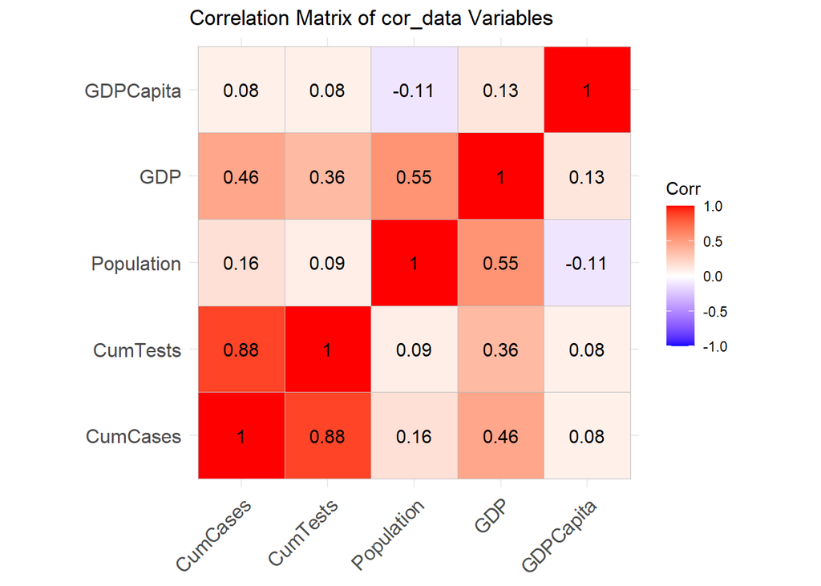

```r
# Calculate the correlation matrix
cor_matrix <- cor(cor_data, use = "complete.obs") # The 'use = "complete.obs"' argument ensures that only complete observations (rows without missing values) are used in the calculation.

# Visualize the correlation matrix
ggcorrplot(cor_matrix, lab = TRUE, title = "Correlation Matrix of cor_data Variables")
```

3. visualize the distribution of the cumulative cases in the cor_data with and without changing the scale of the x axis to log transformation.

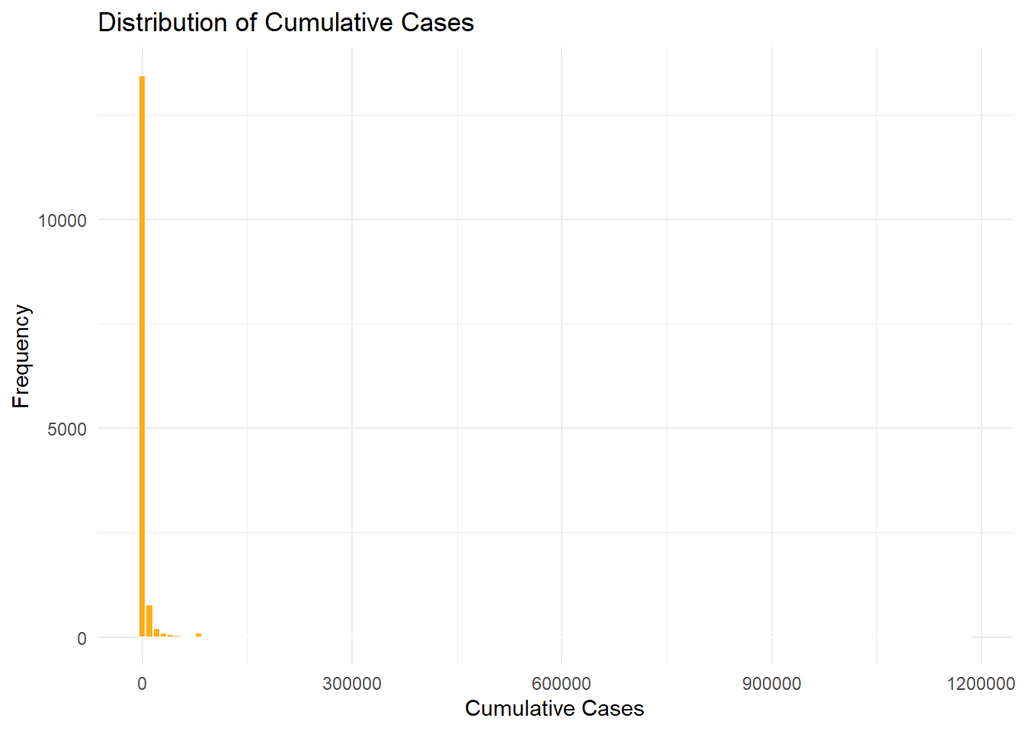

```r
# Plot without log transformation
ggplot(cor_data, aes(x = CumCases)) +  # Initialize a ggplot object using the 'cor_data' dataset, mapping 'CumCases' to the x-axis
  geom_histogram(binwidth = 10000, fill = "orange", color = "white", alpha = 0.9) +  # Create a histogram with specified bin width, fill color, border color, and transparency
  labs(title = "Distribution of Cumulative Cases", x = "Cumulative Cases", y = "Frequency") +  # Set the title and axis labels for the plot
  theme_minimal()  # Apply a minimal theme to the plot for a cleaner appearance
```

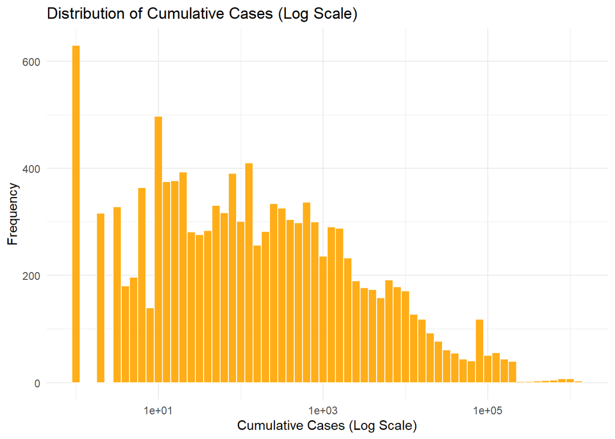

```r
# Plot with log transformation on the x-axis
ggplot(cor_data, aes(x = CumCases)) +  # Initialize another ggplot object using the 'cor_data' dataset, mapping 'CumCases' to the x-axis
  geom_histogram(binwidth = 0.1, fill = "orange", color = "white", alpha = 0.9) +  # Create a histogram with a smaller bin width for finer detail
  scale_x_log10() +  # Apply a logarithmic scale to the x-axis for better visualization of data spread
  labs(title = "Distribution of Cumulative Cases (Log Scale)", x = "Cumulative Cases (Log Scale)", y = "Frequency") +  # Set the title and axis labels for the log-transformed plot
  theme_minimal()  # Apply a minimal theme to the plot for consistency with the first plot
```

4. Divide the cor_data into training and testing, where training data represent 65% of the number of rows.

```r
# Set a seed for reproducibility
set.seed(123)  # Set the random seed to ensure that the results can be reproduced in future runs

# Calculate the number of rows for the training set (65% of total rows)
train_size <- floor(0.65 * nrow(cor_data))  # Calculate 65% of the total number of rows in 'cor_data' for the training set size

# Create a random sample of row indices for the training set
train_indices <- sample(seq_len(nrow(cor_data)), size = train_size)  # Generate random indices for the training set from the total row indices

# Split the data into training and testing sets
train_data <- cor_data[train_indices, ]  # Subset 'cor_data' to create the training dataset using the sampled indices
test_data <- cor_data[-train_indices, ]   # Create the testing dataset by excluding the training indices from 'cor_data'

# Verify the sizes of the datasets
cat("Training data rows:", nrow(train_data), "\n")  # Print the number of rows in the training dataset
```

```
## Training data rows: 9768
```

```r
cat("Testing data rows:", nrow(test_data), "\n")     # Print the number of rows in the testing dataset
```

```
## Testing data rows: 5261
```

5. Train a linear regression model to predict cumulative cases from the GDP of the countries. Then, evaluate this model on the test data and print the root mean square error value.

```r
# Train a linear regression model on the training data
linear_model <- lm(CumCases ~ GDP, data = train_data)  # Fit a linear regression model predicting 'CumCases' based on 'GDP' using the training dataset

# Print the summary of the model to see coefficients and other statistics
summary(linear_model)  # Display detailed statistics of the fitted model, including coefficients, R-squared, and p-values
```

```
##
## Call:
## lm(formula = CumCases ~ GDP, data = train_data)
##
## Residuals:
##     Min      1Q  Median      3Q     Max
## -160102   -2098    -547    -370 1020532
##
## Coefficients:
##              Estimate Std. Error t value Pr(>|t|)
## (Intercept) 4.336e+02  3.722e+02   1.165    0.244
## GDP         8.194e-03  1.606e-04  51.010   <2e-16 ***
## ---
## Signif. codes:  0 '***' 0.001 '**' 0.01 '*' 0.05 '.' 0.1 ' ' 1
##
## Residual standard error: 35340 on 9766 degrees of freedom
## Multiple R-squared:  0.2104, Adjusted R-squared:  0.2103
## F-statistic:  2602 on 1 and 9766 DF,  p-value: < 2.2e-16
```

```r
# Make predictions on the test data
predictions <- predict(linear_model, newdata = test_data)  # Use the trained model to make predictions of 'CumCases' on the testing dataset

# Calculate RMSE
rmse <- sqrt(mean((predictions - test_data$CumCases) ^ 2))  # Calculate the Root Mean Square Error (RMSE) to assess the prediction accuracy

# Print the RMSE value
cat("Root Mean Square Error (RMSE):", rmse, "\n")  # Output the RMSE value to evaluate the model's performance
```

```
## Root Mean Square Error (RMSE): 37856.72
```

6. Train another linear regression model to predict cumulative cases from all the other variables. Then, evaluate this model on the test data and print the root mean square error value.

```r
# Train a linear regression model using CumTests, Population, GDP, and GDPCapita to predict CumCases
alternative_prediction_model <- lm(CumCases ~ CumTests + Population + GDP + GDPCapita, data = train_data)  # Fit a linear regression model predicting 'CumCases' based on multiple predictors: 'CumTests', 'Population', 'GDP', and 'GDPCapita' using the training dataset

# Print the summary of the model to see coefficients and other statistics
summary(alternative_prediction_model)  # Display detailed statistics of the fitted model, including coefficients, R-squared, and p-values
```

```
##
## Call:
## lm(formula = CumCases ~ CumTests + Population + GDP + GDPCapita,
##     data = train_data)
##
## Residuals:
##     Min      1Q  Median      3Q     Max
## -347651     350    1323    1632  286690
##
## Coefficients:
##               Estimate Std. Error t value Pr(>|t|)
## (Intercept) -1.303e+03  2.562e+02  -5.085 3.74e-07 ***
## CumTests     1.143e-01  7.413e-04 154.144  < 2e-16 ***
## Population  -2.831e-06  1.317e-06  -2.150   0.0316 *
## GDP          3.322e-03  1.138e-04  29.187  < 2e-16 ***
## GDPCapita   -1.763e-02  7.112e-03  -2.478   0.0132 *
## ---
## Signif. codes:  0 '***' 0.001 '**' 0.01 '*' 0.05 '.' 0.1 ' ' 1
##
## Residual standard error: 18920 on 9763 degrees of freedom
## Multiple R-squared:  0.7738, Adjusted R-squared:  0.7737
## F-statistic:  8349 on 4 and 9763 DF,  p-value: < 2.2e-16
```

```r
# Make predictions on the test data
alternative_predictions <- predict(alternative_prediction_model, newdata = test_data)  # Use the trained model to make predictions of 'CumCases' on the testing dataset

# Calculate RMSE
alternative_rmse <- sqrt(mean((alternative_predictions - test_data$CumCases) ^ 2))  # Calculate the Root Mean Square Error (RMSE) to assess the prediction accuracy of the alternative model

# Print the RMSE value
cat("Root Mean Square Error (RMSE):", alternative_rmse, "\n")  # Output the RMSE value to evaluate the performance of the alternative model
```

```
## Root Mean Square Error (RMSE): 17883.27
```

7. Interpret the two models and write a small report of highlighting the differences between using the two models. For example, in which cases we should use the first model and in which cases the second one is better to use.

**Interpretation goes below here**:

Model 1, which predicts cumulative cases based on GDP, is valuable for exploratory analysis, serving as a foundation for more complex models and acting as a benchmark for comparisons. It helps understand trends related to GDP fluctuations, aiding policymakers and public health officials in evaluating the economic impact on health outcomes. While useful for preliminary predictions, it has limited explanatory power and may require additional variables for improved accuracy. Caution is advised when relying on its results.